# Part I - The Loan Original Amount For Borrowers And Its Interactions With Some Other Loan Features

### Exploration_B9

#### Question:

> How is the Loan Status and the Prosper Score related to each other?

#### Visualization:

```python
df_clean.LoanStatus.value_counts()
```

```
Current                   55157
Completed                 38043
Chargedoff                11992
Defaulted                  5017
Past Due (1-15 days)        805
Past Due (31-60 days)       363
Past Due (61-90 days)       312
Past Due (91-120 days)      304
Past Due (16-30 days)       265
FinalPaymentInProgress      202
Past Due (>120 days)         16
Cancelled                     5
Name: LoanStatus, dtype: int64
```

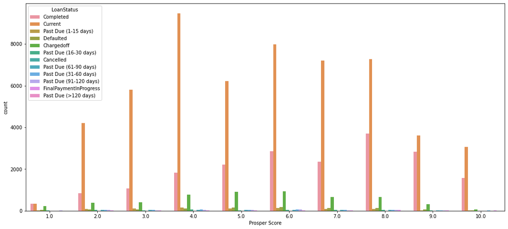

```python
plt.figure(figsize=(18, 8))

# Converting the "ProsperScore" column from a plain object type into an ordered categorical type

prosper_score = [1.0, 2.0, 3.0, 4.0, 5.0, 6.0, 7.0, 8.0, 9.0, 10.0]
pscore = pd.api.types.CategoricalDtype(ordered=True, categories=prosper_score)
df_clean['ProsperScore'] = df_clean['ProsperScore'].astype(pscore);



# The existing `LoanStatus` column has multiple sub-types of Automatic and Manual.
# But, we need plain two types, either Automatic or Manual. Therefore, add a new column.

# The Series.apply() method invokes the `lambda` function on each value of `trans` column.
# In python, a `lambda` function is an anonymous function that can have only one expression.
#df['LoanStatus'] = df['LoanStatus'].apply(lambda x:x.split()[0])
#fuel_econ.head()

palette =sb.set_palette("dark")

sb.countplot(data = df_clean, x = 'ProsperScore', hue = 'LoanStatus', color = palette)
plt.xlabel('Prosper Score')
plt.show()
```

### Did you observe any interesting relationships between the other features (not the main feature(s) of interest)?

> Majority of the borrowers who were given loans for scoring 4.0 on the Prosper score scale had current loans.